# Predicting Turnover - HR

Mohammed Al Haqbani

5/14/2024

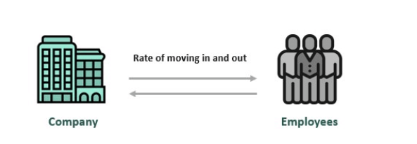

# 1 Introduction

In today’s competitive business environment, understanding employee turnover is crucial for organizational success. Turnover refers to the rate at which employees leave a company and are replaced by new employees. High turnover rates can lead to significant costs for a company, including the expenses associated with recruiting, hiring, and training new employees, as well as the loss of productivity and institutional knowledge. Therefore, it is essential for human resources departments to monitor and analyze turnover rates to devise effective retention strategies.

This analysis aims to explore the patterns of employee turnover within a hypothetical company, leveraging historical data to identify key factors that contribute to employee departure. By utilizing advanced statistical methods and predictive modeling, this study provides insights that can help the organization enhance its employee retention strategies and improve overall workforce management.

# 2 Objective

This analysis is structured to achieve several key objectives that are critical for enhancing employee retention strategies. These objectives are divided into two main categories:

### 2.0.1 Predictive Insights

- **Understand Turnover Trends:** Analyze historical data to discern the trends of employee turnover over different periods.
- **Develop Predictive Models:** Construct models to predict potential turnover, enabling proactive strategies to mitigate it.

### 2.0.2 Strategic Actions

- **Identify Key Factors:** Determine factors such as employee level and location that significantly impact turnover rates.
- **Inform Strategic Decisions:** Deliver actionable insights to assist HR and management in making informed policy and practice decisions.
- **Enhance Employee Retention:** Propose targeted strategies to improve employee retention and reduce turnover costs.

By systematically addressing these objectives, the analysis aims to empower the organization with the necessary insights and tools to foster a stable and engaged workforce, ultimately enhancing overall organizational performance.

## 2.1 libraries

```r
library(caret)
library(tidyverse)
library(lubridate)
library(readxl)
library(lubridate)
library(scales)
library(Information)
library(car)
library(tidypredict)
library(gt)
```

## 2.2 The dataset

```r
org_tbl <- read_csv ("/Users/haqbani/Library/CloudStorage/Dropbox/10 _Miscellaneous/2 _perosnal_projects/R/predecting_employee_churn_in_r_05122024/employee_data (1)/org.csv")
rating_tbl <- read_csv("/Users/haqbani/Library/CloudStorage/Dropbox/10 _Miscellaneous/2 _perosnal_projects/R/predecting_employee_churn_in_r_05122024/employee_data (1)/rating.csv")
survey_tbl <- read_csv("/Users/haqbani/Library/CloudStorage/Dropbox/10 _Miscellaneous/2 _perosnal_projects/R/predecting_employee_churn_in_r_05122024/employee_data (1)/survey.csv")
org_final_tbl <- read.csv("/Users/haqbani/Library/CloudStorage/Dropbox/10 _Miscellaneous/2 _perosnal_projects/R/predecting_employee_churn_in_r_05122024/employee_data (1)/org_final.csv")
org_fina_2 <- read_csv("/Users/haqbani/Library/CloudStorage/Dropbox/10 _Miscellaneous/2 _perosnal_projects/R/predecting_employee_churn_in_r_05122024/employee_data (1)/org_final.csv")
```

# 3 Explore the data

```r
org_tbl %>% head() %>% gt()
```

| emp_id | status | turnover | location | level | date_of_joining | date_of_birth | last_working_date | gender | department | mgr_id | cutoff_date | generation | emp_age |
| --- | --- | --- | --- | --- | --- | --- | --- | --- | --- | --- | --- | --- | --- |
| E11061 | Inactive | 1 | New York | Analyst | 22/03/2012 | 22/03/1992 | 11/09/2014 | Male | Customer Operations | E1712 | 31/12/2014 | Millennials | 22.5 |
| E1031 | Inactive | 1 | New York | Analyst | 09/03/2012 | 10/01/1992 | 05/06/2014 | Female | Customer Operations | E10524 | 31/12/2014 | Millennials | 22.4 |
| E6213 | Inactive | 1 | New York | Analyst | 06/01/2012 | 06/02/1992 | 30/04/2014 | Female | Customer Operations | E4443 | 31/12/2014 | Millennials | 22.2 |
| E5900 | Inactive | 1 | New York | Analyst | 22/03/2012 | 19/12/1991 | 09/04/2014 | Female | Customer Operations | E3638 | 31/12/2014 | Millennials | 22.3 |
| E3044 | Inactive | 1 | Florida | Analyst | 29/03/2012 | 10/12/1991 | 23/01/2014 | Female | Customer Operations | E3312 | 31/12/2014 | Millennials | 22.1 |
| E4008 | Active | 0 | Florida | Assistant Manager | 27/11/2013 | 06/05/1992 | NA | Female | Customer Operations | E13933 | 31/12/2014 | Millennials | 23.0 |

```r
rating_tbl %>% head() %>% gt()
```

| emp_id | rating |
| --- | --- |
| E8 | Acceptable |
| E9 | Acceptable |
| E12 | Acceptable |
| E15 | Acceptable |
| E34 | Acceptable |
| E37 | Unacceptable |

```r
survey_tbl %>% head() %>% gt()
```

| mgr_id | mgr_effectiveness | career_satisfaction | perf_satisfaction | work_satisfaction |
| --- | --- | --- | --- | --- |
| E1003 | 0.76 | 0.76 | 0.71 | 0.82 |
| E10072 | 0.65 | 0.67 | 0.56 | 0.84 |
| E10081 | 0.80 | 0.82 | 0.73 | 0.84 |
| E10234 | 0.65 | 0.63 | 0.75 | 0.70 |
| E1026 | 0.70 | 1.00 | 1.00 | 0.92 |
| E10422 | 0.98 | 0.91 | 0.91 | 0.77 |

# 4 Calculate Turnover

in order to calculate the turnover we need to create a new column called turnover and assign 0 to active employees and 1 to inactive employee

```r
org_tbl <- org_tbl %>%
    mutate(turnover = ifelse(status == "Active",0, 1)) %>%
    glimpse()
```

### 4.0.1 What proportion of employees have left?

As per the below results, we can see that 18% of the employees have left the company.

## 4.1 Attention

The 18% is referring to the entire data without considering the dates. Hence, in other words, 18% employee have left for the whole period of operating the company.

```r
org_tbl %>%
    summarize(turnover_rate = percent(mean(turnover, na.rm = TRUE))) %>% gt()
```

| turnover_rate |
| --- |
| 18% |

### 4.1.1 What levels have high turnover rate?

```r
plot1 <- org_tbl %>%
    group_by(level) %>%
    summarize(turnover_rate = mean(turnover)) %>%
    ggplot(aes(x = level, y = turnover_rate)) +
    geom_col(fill = "#091E57")+
    labs(title = "Turnover Rate by Level",
         x = "Level",
         y = "Turnover Rate")
```

### 4.1.2 Is turnover rate different across locations?

```r
plot2 <- org_tbl %>%
    group_by(location) %>%
    summarize(turnover_rate = mean(turnover, na.rm = TRUE)) %>%
    ggplot(aes(x = location, y = turnover_rate)) +
    geom_col(fill = "#091E57")
```

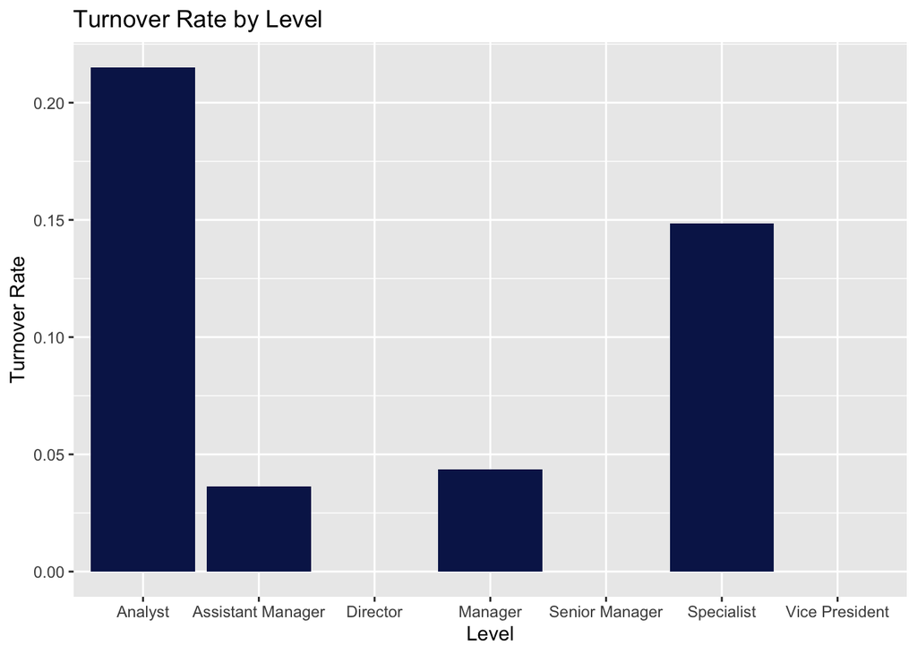

```r
print(plot1)
```

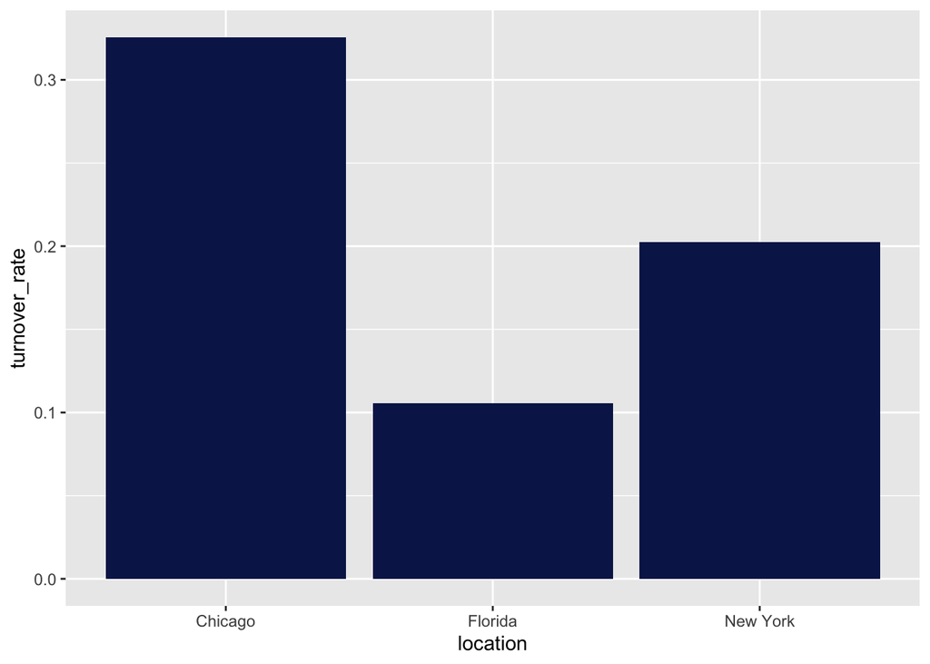

```r
print(plot2)
```

### 4.1.3 Counting the number of employees in each level

```r
org_tbl %>%
    group_by(level) %>%
    count()
```

```
## # A tibble: 7 × 2
## # Groups:   level [7]
##   level                 n
##   <chr>             <int>
## 1 Analyst            1604
## 2 Assistant Manager   192
## 3 Director              1
## 4 Manager             138
## 5 Senior Manager        5
## 6 Specialist          350
## 7 Vice President        1
```

### 4.1.4 Filtering & count

the dataset to select only Analyst and Specialist

```r
org_tbl %>%
    filter(level == "Analyst" | level == "Specialist")
```

```
## # A tibble: 1,954 × 14
##    emp_id status   turnover location level      date_of_joining date_of_birth
##    <chr>  <chr>       <dbl> <chr>    <chr>      <chr>           <chr>
##  1 E11061 Inactive        1 New York Analyst    22/03/2012      22/03/1992
##  2 E1031  Inactive        1 New York Analyst    09/03/2012      10/01/1992
##  3 E6213  Inactive        1 New York Analyst    06/01/2012      06/02/1992
##  4 E5900  Inactive        1 New York Analyst    22/03/2012      19/12/1991
##  5 E3044  Inactive        1 Florida  Analyst    29/03/2012      10/12/1991
##  6 E6636  Active          0 New York Specialist 17/02/2012      23/01/1992
##  7 E13796 Inactive        1 New York Analyst    30/03/2012      19/12/1990
##  8 E13549 Active          0 New York Analyst    09/03/2012      22/12/1991
##  9 E13430 Inactive        1 New York Analyst    09/03/2012      19/08/1991
## 10 E13349 Active          0 New York Analyst    09/03/2012      23/11/1991
## # ℹ 1,944 more rows
## # ℹ 7 more variables: last_working_date <chr>, gender <chr>,
## #   department <chr>, mgr_id <chr>, cutoff_date <chr>, generation <chr>,
## #   emp_age <dbl>
```

```r
org_tbl %>%
    filter(level == "Analyst" | level == "Specialist") %>%
    group_by(level) %>%
    count()
```

```
## # A tibble: 2 × 2
## # Groups:   level [2]
##   level          n
##   <chr>      <int>
## 1 Analyst     1604
## 2 Specialist   350
```

# 5 Joining the tables

Joining the rating tbl with org tbl using left join by the emp_id

```r
org_tbl %>% glimpse()
rating_tbl %>% glimpse()


joined_tbl <- org_tbl %>%
    left_join(rating_tbl, by = "emp_id") %>% glimpse()


joined_tbl %>%
    group_by(rating) %>%
    summarize(turnover_rate = mean(turnover, na.rm = TRUE)) %>% glimpse()
```

[output not shown]

Joining the survey_tbl with joined_tbl using left_join by the mgr_id

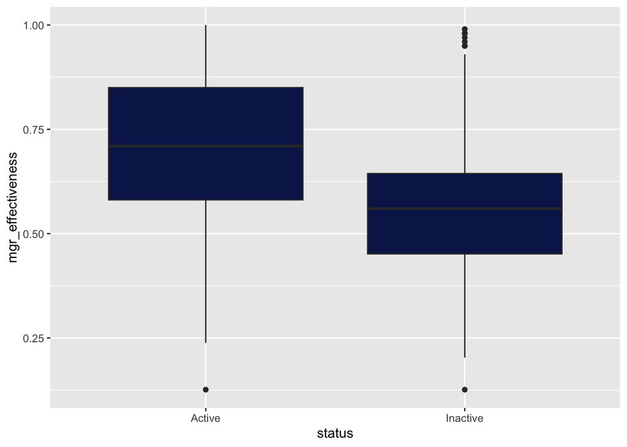

```r
joined_tbl <- joined_tbl %>%
    left_join(survey_tbl, by = "mgr_id") %>%
    group_by(status)

joined_tbl %>%
select(status, mgr_effectiveness) %>%
    ggplot(aes(x = status, y = mgr_effectiveness)) +
    geom_boxplot(fill = "#091E57")
```

### 5.0.1 Distance from home to work

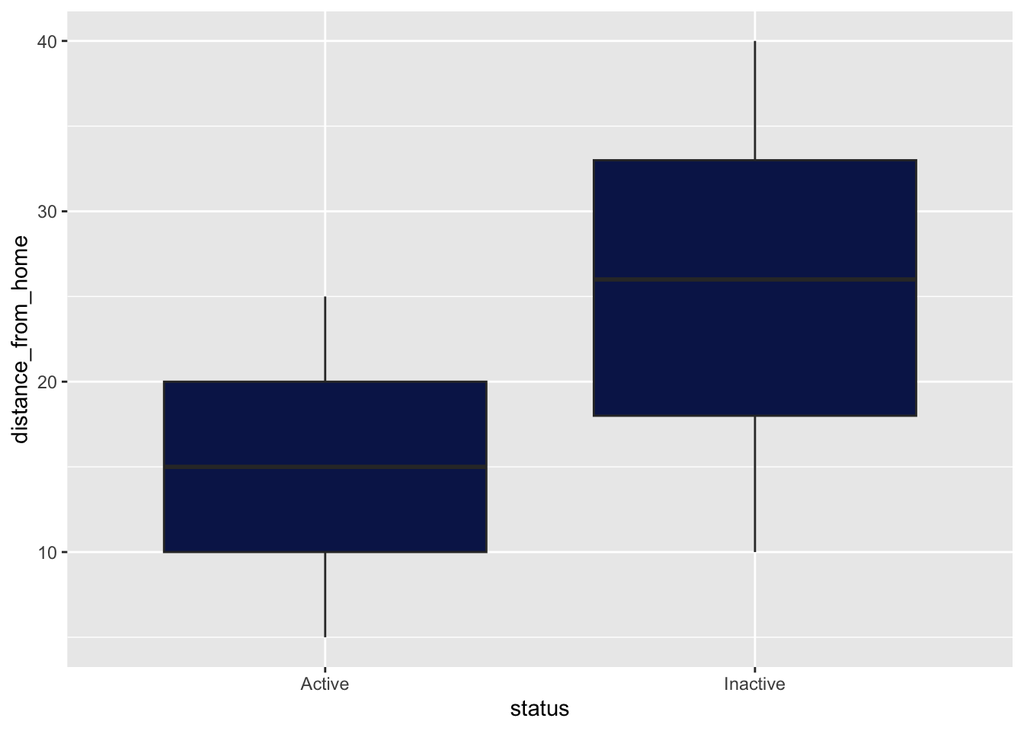

```r
org_final_tbl %>%
    select(status, distance_from_home) %>%
    ggplot(aes(x = status, y = distance_from_home)) +
    geom_boxplot(fill = "#091E57")
```

### 5.0.2 Age difference between employees and managers

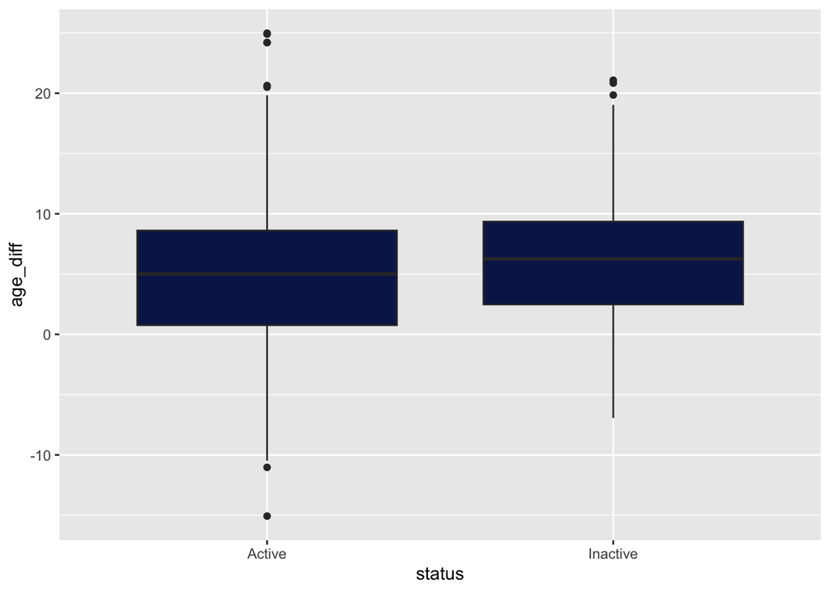

```r
org_final_tbl %>%
    select(emp_age, mgr_age, status) %>%
    mutate(age_diff = mgr_age - emp_age) %>%
    ggplot(aes(x = status, y = age_diff)) +
    geom_boxplot(fill = "#091E57")
```

# 6 Calcute the job hob index for each employee

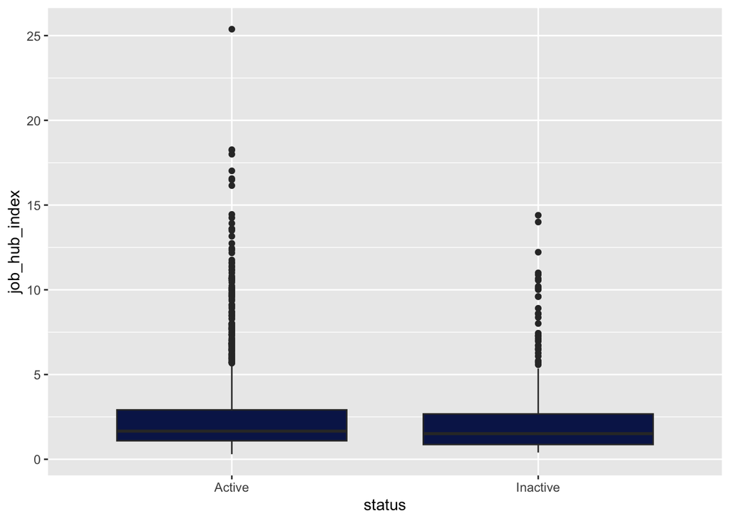

```r
org_final_tbl %>%
    select(status, total_experience, no_previous_companies_worked) %>%
    mutate(job_hub_index = total_experience/no_previous_companies_worked) %>%
    ggplot(aes(x = status, y = job_hub_index)) +
    geom_boxplot(fill = "#091E57")
```

# 7 Compensation distribution

```
## Rows: 1,954
## Columns: 6
## $ compensation      <int> 64320, 48204, 85812, 49536, 75576, 56904, 38772, 5…
## $ status            <chr> "Active", "Active", "Active", "Active", "Active", …
## $ date_of_joining   <date> 2011-03-06, 2009-09-23, 2005-11-02, 2011-05-20, 2…
## $ cutoff_date       <date> 2014-12-31, 2014-12-31, 2014-12-31, 2014-12-31, 2…
## $ last_working_date <date> NA, NA, NA, NA, NA, 2014-12-11, NA, NA, NA, 2014-…
## $ tenure            <dbl> 3.821918, 5.271233, 9.161644, 3.616438, 3.027397, …
```

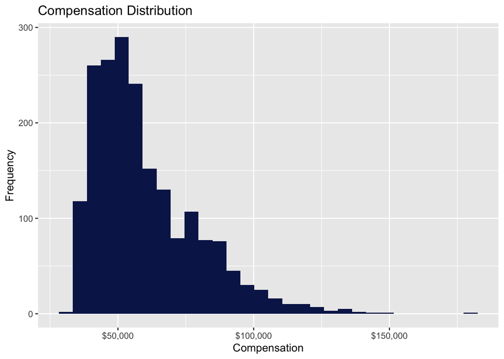

```r
org_final_tbl %>%
    select(compensation, status, date_of_joining, cutoff_date, last_working_date) %>%
    mutate(date_of_joining = as.Date(date_of_joining, format = "%d/%m/%Y"),
           cutoff_date = as.Date(cutoff_date, format = "%d/%m/%Y"),
           last_working_date = as.Date(last_working_date, format = "%d/%m/%Y"),
           tenure = ifelse(
               status == "Active",
               time_length(interval(date_of_joining, cutoff_date), "years"),
               time_length(interval(date_of_joining, last_working_date), "years"))) %>%
    glimpse() %>%
    ggplot(aes(x = compensation))+
    geom_histogram(fill = "#091E57", bins = 30)+
    scale_x_continuous(labels = scales::dollar_format())+
    labs(title = "Compensation Distribution",
         x = "Compensation",
         y = "Frequency")
```

## 7.1 Explore the distrpution of compensation by level

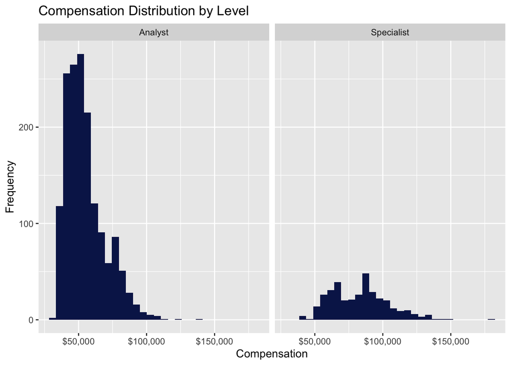

```r
org_final_tbl %>%
    select(compensation, level) %>%
    ggplot(aes(x = compensation))+
    geom_histogram(fill = "#091E57", bins = 30)+
    scale_x_continuous(labels = scales::dollar_format())+
    labs(title = "Compensation Distribution by Level",
         x = "Compensation",
         y = "Frequency")+
    facet_wrap(~level)
```

## 7.2 Explore the distribution of compensation by states

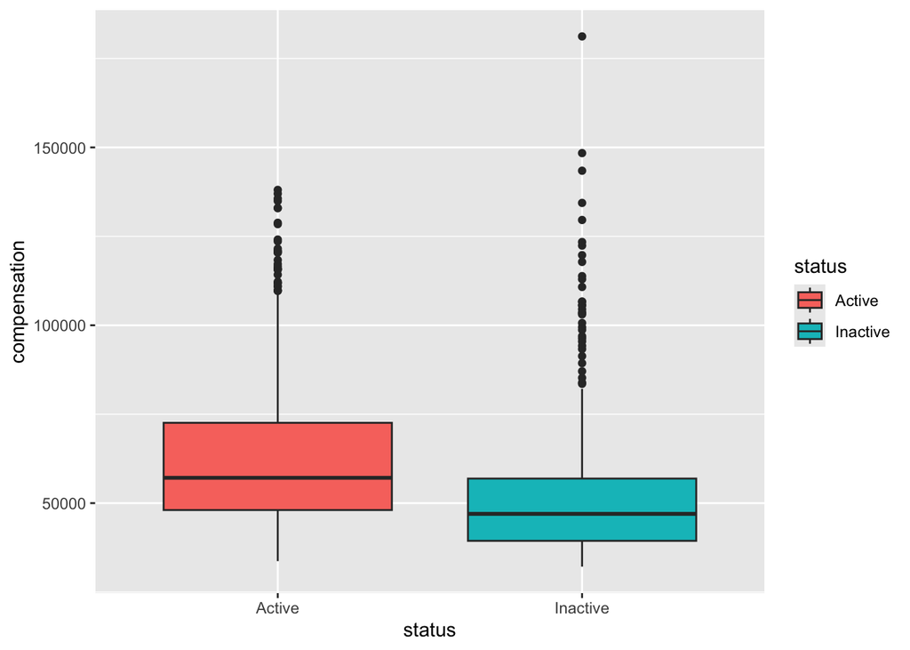

```r
org_final_tbl %>%
    select(compensation, status) %>%
    ggplot(aes(x= status, y = compensation, fill = status))+
    geom_boxplot()
```

## 7.3 Calculate the compo-ratio

```r
org_final_tbl %>%
    select(compensation, level, status) %>%
    group_by(level) %>%
    summarize(median_compensation = median(compensation))
```

[output not shown]

## 7.4 Calculate the compo-ratio for each employee

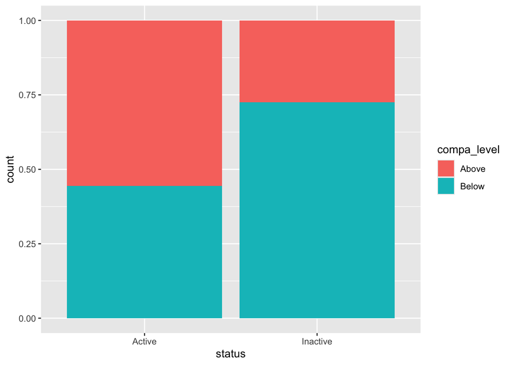

```r
compa_ratio <- org_final_tbl %>%
    select(compensation, level, status) %>%
    mutate(comp_ratio = compensation/median(compensation))

compa_ratio %>%
    mutate(compa_level = ifelse(comp_ratio > 1, "Above", "Below")) %>%
    ggplot(aes(x = status, fill = compa_level))+
    geom_bar(position = "fill")
```

# 8 Informaion power

measuring and ranking the variables on the basis of the predictive power of each variable i will have to convert the the dates to Date i have to calculate the tenure of each employee again since did not saved it 😁

```r
org_final_tbl <- org_final_tbl %>%
    mutate(date_of_joining = as.Date(date_of_joining, format("%d/%m/%Y"))) %>%
    mutate(cutoff_date = as.Date(cutoff_date, format("%d/%m/%Y"))) %>%
    mutate(last_working_date = as.Date(last_working_date, format("%d/%m/%Y"))) %>%
    mutate(tenure = ifelse(status == "Active",
                           time_length(interval(date_of_joining, cutoff_date), "years"),
                           time_length(interval(date_of_joining, last_working_date), "years"))) %>%
    glimpse()
```

```r
iv <- create_infotables(data = org_final_tbl, y = "turnover")
```

```
## [1] "Variable emp_id was removed because it is a non-numeric variable with >1000 categories"
## [1] "Variable date_of_joining was removed because it is a Date variable"
## [1] "Variable last_working_date was removed because it is a Date variable"
## [1] "Variable department was removed because it has only 1 unique value"
## [1] "Variable cutoff_date was removed because it is a Date variable"
```

```r
iv$Summary %>% gt()
```

| Variable | IV |
| --- | --- |
| percent_hike | 1.144784e+00 |
| total_dependents | 1.088645e+00 |
| no_leaves_taken | 9.404533e-01 |
| tenure | 9.332570e-01 |
| mgr_effectiveness | 6.830020e-01 |
| compensation | 6.074885e-01 |
| rating | 3.869373e-01 |
| monthly_overtime_hrs | 3.786644e-01 |
| mgr_reportees | 3.620543e-01 |
| location | 2.963023e-01 |
| mgr_id | 2.820235e-01 |
| emp_age | 2.275477e-01 |
| distance_from_home | 1.470549e-01 |
| work_satisfaction | 1.378953e-01 |
| total_experience | 1.345781e-01 |
| education | 1.253865e-01 |
| promotion_last_2_years | 9.979915e-02 |
| mgr_age | 9.816205e-02 |
| perf_satisfaction | 7.099511e-02 |
| hiring_score | 6.684727e-02 |
| mgr_tenure | 5.918048e-02 |
| career_satisfaction | 3.539857e-02 |
| level | 2.726491e-02 |
| marital_status | 2.588063e-02 |
| mgr_rating | 2.172222e-02 |
| no_previous_companies_worked | 1.729893e-02 |
| hiring_source | 8.773529e-03 |
| gender | 3.959968e-05 |
| status | 0.000000e+00 |

## 8.1 Spliting the data

into training and testing with caret into 70% / 30%

```r
set.seed(567)
index_train <- createDataPartition(org_final_tbl$turnover, p=0.7, list = FALSE)

train_set <- org_final_tbl[index_train,]
test_set <- org_final_tbl[-index_train,]
```

## 8.2 Data Validation

Make sure that the data you are training your model is representative

```r
train_set %>%
    count(status) %>%
    mutate(prop = n/sum(n)*100)
test_set %>%
    count(status) %>%
    mutate(prop = n/sum(n)*100)
```

[output not shown]

# 9 Building the model

Logistic regression

```r
train_set_multi <- train_set %>%
    select(-c(emp_id, mgr_id, date_of_joining,
              last_working_date, cutoff_date, status,
              compensation, department, mgr_age, emp_age))
```

Miltiy verible logistic regression

```r
multi_log <- glm(turnover ~ ., data = train_set_multi, family = "binomial")
summary(multi_log)
```

```
##
## Call:
## glm(formula = turnover ~ ., family = "binomial", data = train_set_multi)
##
## Coefficients:
##                                  Estimate Std. Error z value Pr(>|z|)
## (Intercept)                    -11.273866   3.654271  -3.085 0.002035 **
## locationNew York                 0.800174   0.451662   1.772 0.076457 .
## locationOrlando                 -0.899250   0.385450  -2.333 0.019649 *
## levelSpecialist                 16.043696 664.444331   0.024 0.980736
## genderMale                       0.264781   0.325822   0.813 0.416416
## ratingAcceptable                 0.069918   0.374629   0.187 0.851949
## ratingBelow Average             -2.428636   0.687490  -3.533 0.000411 ***
## ratingExcellent                 -0.489863   0.845190  -0.580 0.562192
## ratingUnacceptable              -4.398533   1.191159  -3.693 0.000222 ***
## mgr_ratingAcceptable            -0.052624   0.358636  -0.147 0.883343
## mgr_ratingBelow Average         -0.933924   0.658698  -1.418 0.156239
## mgr_ratingExcellent             -0.560799   0.506963  -1.106 0.268643
## mgr_ratingUnacceptable           0.981136   1.246629   0.787 0.431263
## mgr_reportees                    0.091859   0.029738   3.089 0.002009 **
## mgr_tenure                      -0.009668   0.043724  -0.221 0.825005
## percent_hike                    -0.574188   0.078980  -7.270 3.59e-13 ***
## hiring_score                     0.060484   0.042570   1.421 0.155375
## hiring_sourceConsultant         -0.611602   0.530563  -1.153 0.249016
## hiring_sourceEmployee Referral  -0.510566   0.609831  -0.837 0.402466
## hiring_sourceJob Boards         -0.777472   0.593154  -1.311 0.189945
## hiring_sourceJob Fairs          -0.629813   0.561958  -1.121 0.262395
## hiring_sourceSocial Media       -0.236317   0.565215  -0.418 0.675873
## hiring_sourceWalk-In            -0.471294   0.575516  -0.819 0.412840
## no_previous_companies_worked    -0.015953   0.053036  -0.301 0.763572
## distance_from_home               0.206045   0.022587   9.122  < 2e-16 ***
## total_dependents                 0.773542   0.113580   6.811 9.72e-12 ***
## marital_statusSingle             2.603319   0.542350   4.800 1.59e-06 ***
## educationMasters                 1.972339   0.558119   3.534 0.000409 ***
## promotion_last_2_yearsYes      -15.281776 664.444245  -0.023 0.981651
## no_leaves_taken                  0.106464   0.019834   5.368 7.97e-08 ***
## total_experience                -0.067592   0.056412  -1.198 0.230850
## monthly_overtime_hrs             0.241108   0.041776   5.771 7.86e-09 ***
## mgr_effectiveness              -10.009058   1.464273  -6.836 8.17e-12 ***
## career_satisfaction              3.612919   1.425506   2.534 0.011261 *
## perf_satisfaction                2.171362   1.249853   1.737 0.082335 .
## work_satisfaction                1.543645   1.448655   1.066 0.286617
## tenure                          -0.365713   0.097811  -3.739 0.000185 ***
## ---
## Signif. codes:  0 '***' 0.001 '**' 0.01 '*' 0.05 '.' 0.1 ' ' 1
##
## (Dispersion parameter for binomial family taken to be 1)
##
##     Null deviance: 1370.21  on 1367  degrees of freedom
## Residual deviance:  349.78  on 1331  degrees of freedom
## AIC: 423.78
##
## Number of Fisher Scoring iterations: 17
```

## 9.1 Multicollinearity

```r
vif(multi_log)

model_1 <- glm(turnover ~ ., family = "binomial",
              data = train_set_multi)
vif(model_1)

highest <- "level"
model_2 <- update(model_1, . ~ . - level)
vif(model_2)
```

[output not shown]

# 10 Predicting employee turnover

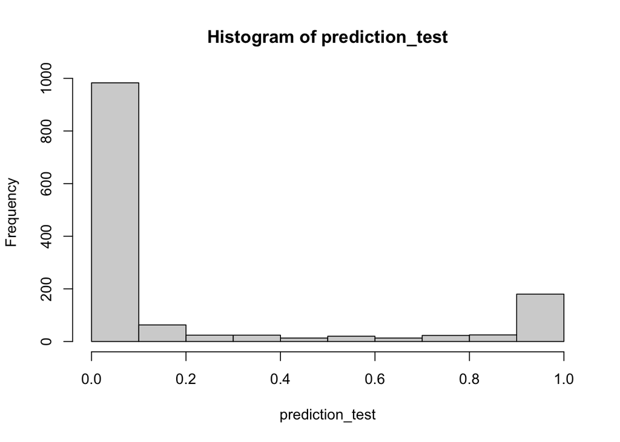

```r
final_log <- glm(turnover ~ ., family = "binomial",
                 data = train_set_multi)

prediction_test <- predict(final_log, type = "response")

hist(prediction_test)
```

```r
enp_risk <- org_final_tbl %>%
    filter(status == "Active") %>%
    tidypredict_to_column(final_log)
```

## 10.1 The top 10 employees at risk of leaving

```r
enp_risk %>%
    select(emp_id, fit) %>%
    slice_max(fit, n = 10) %>% gt()
```

| emp_id | fit |
| --- | --- |
| E6037 | 0.9414980 |
| E13342 | 0.9287730 |
| E202 | 0.9227587 |
| E9878 | 0.8915216 |
| E6475 | 0.8698359 |
| E12616 | 0.8670915 |
| E12291 | 0.8602353 |
| E1355 | 0.8512867 |
| E8253 | 0.8282859 |
| E12447 | 0.8132396 |

## 10.2 Classification of the employees at risk of leaving

```r
emp_risk_bukets. <- enp_risk %>%
    mutate(risk_bucket = cut(fit, breaks = c(0,0.5,0.6,0.8,1),
           labels = c("no_risk", "low_risk", "medium_risk", "high_risk"))) %>%
    glimpse() %>% gt()
```

```
## Rows: 1,557
## Columns: 37
## $ emp_id                       <chr> "E10012", "E10025", "E10027", "E10048",…
## $ status                       <chr> "Active", "Active", "Active", "Active",…
## $ location                     <chr> "New York", "Chicago", "Orlando", "Chic…
## $ level                        <chr> "Analyst", "Analyst", "Specialist", "Sp…
## $ gender                       <chr> "Female", "Female", "Female", "Male", "…
## $ emp_age                      <dbl> 25.09, 25.98, 33.40, 24.55, 31.23, 24.8…
## $ rating                       <chr> "Above Average", "Acceptable", "Accepta…
## $ mgr_rating                   <chr> "Acceptable", "Excellent", "Above Avera…
## $ mgr_reportees                <int> 9, 4, 6, 10, 11, 21, 9, 12, 17, 21, 15,…
## $ mgr_age                      <dbl> 44.07, 35.99, 35.78, 26.70, 34.28, 24.9…
## $ mgr_tenure                   <dbl> 3.17, 7.92, 4.38, 2.87, 12.95, 4.01, 4.…
## $ compensation                 <int> 64320, 48204, 85812, 49536, 75576, 3877…
## $ percent_hike                 <int> 10, 8, 11, 8, 12, 12, 9, 9, 11, 14, 16,…
```

[output cut: 24 more lines]